# Subsección 2

Carlos López

2025-04-12

# Instrucciones

Actividad 1: Con funciones de la librería {dplyr} para obtener el número total de incidentes, número total de accidentes fatales y el número total de muertes en el periodo de 1985 a 2014.

Actividad 2: Obtenga las 10 aerolíneas que han tenido el mayor número de incidentes. Haga una visualización que permita identificar a éstas. ¿Hay algún cambio en este top 10 antes y después del año 2000?

Actividad 3: Obtenga las 10 aerolíneas que han tenido el menor número de incidentes. Haga una visualización que permita identificar a éstas. ¿Hay algún cambio en este top 10 antes y después del año 2000?

Actividad 4: Obtenga las 10 aerolíneas que han tenido el mayor número de muertes. Haga una visualización que permita identificar a éstas. ¿Hay algún cambio en este top 10 antes y después del año 2000?

Actividad 5: Obtenga las 10 aerolíneas que han tenido el menor número de muertes. Haga una visualización que permita identificar a éstas. ¿Hay algún cambio en este top 10 antes y después del año 2000?

Importante: Sus visualizaciones deben tener formato suficientemente bueno para publicar en alguna revista.

# Importo los datos de la librería de seguridad de vuelos

```r
datos_vuelos <- fivethirtyeight::airline_safety
```

## Cargo las librerías necesarias.

```r
library(dplyr)
```

```r
library(ggplot2)
library(tidyr)
```

- Exploro con un head qué contiene el df.

```r
head(datos_vuelos)
```

```
## # A tibble: 6 × 9
##   airline           incl_reg_subsidiaries avail_seat_km_per_week incidents_85_99
##   <chr>             <lgl>                                  <dbl>           <int>
## 1 Aer Lingus        FALSE                              320906734               2
## 2 Aeroflot          TRUE                              1197672318              76
## 3 Aerolineas Argen… FALSE                              385803648               6
## 4 Aeromexico        TRUE                               596871813               3
## 5 Air Canada        FALSE                             1865253802               2
## 6 Air France        FALSE                             3004002661              14
## # ℹ 5 more variables: fatal_accidents_85_99 <int>, fatalities_85_99 <int>,
## #   incidents_00_14 <int>, fatal_accidents_00_14 <int>, fatalities_00_14 <int>
```

- Con un str.

```r
str(datos_vuelos)
```

```
## tibble [56 × 9] (S3: tbl_df/tbl/data.frame)
##  $ airline               : chr [1:56] "Aer Lingus" "Aeroflot" "Aerolineas Argentinas" "Aeromexico" ...
##  $ incl_reg_subsidiaries : logi [1:56] FALSE TRUE FALSE TRUE FALSE FALSE ...
##  $ avail_seat_km_per_week: num [1:56] 3.21e+08 1.20e+09 3.86e+08 5.97e+08 1.87e+09 ...
##  $ incidents_85_99       : int [1:56] 2 76 6 3 2 14 2 3 5 7 ...
##  $ fatal_accidents_85_99 : int [1:56] 0 14 0 1 0 4 1 0 0 2 ...
##  $ fatalities_85_99      : int [1:56] 0 128 0 64 0 79 329 0 0 50 ...
##  $ incidents_00_14       : int [1:56] 0 6 1 5 2 6 4 5 5 4 ...
##  $ fatal_accidents_00_14 : int [1:56] 0 1 0 0 0 2 1 1 1 0 ...
##  $ fatalities_00_14      : int [1:56] 0 88 0 0 0 337 158 7 88 0 ...
```

## Actividad 1

Actividad 1: Con funciones de la librería {dplyr} para obtener el número total de incidentes, número total de accidentes fatales y el número total de muertes en el periodo de 1985 a 2014.

- Creo nuevas columnas con los totales del período 1985-2014

```r
datos_vuelos <- datos_vuelos %>% mutate(incidents_85_14 = incidents_85_99+incidents_00_14,
                        fatal_accidents_85_14 = fatal_accidents_85_99+fatal_accidents_00_14,
                        fatalities_85_14 = fatalities_85_99+fatalities_00_14
                        )
```

- Compruebo que se crearon las nuevas columnas.

```r
head(datos_vuelos)
```

```
## # A tibble: 6 × 12
##   airline           incl_reg_subsidiaries avail_seat_km_per_week incidents_85_99
##   <chr>             <lgl>                                  <dbl>           <int>
## 1 Aer Lingus        FALSE                              320906734               2
## 2 Aeroflot          TRUE                              1197672318              76
## 3 Aerolineas Argen… FALSE                              385803648               6
## 4 Aeromexico        TRUE                               596871813               3
## 5 Air Canada        FALSE                             1865253802               2
## 6 Air France        FALSE                             3004002661              14
## # ℹ 8 more variables: fatal_accidents_85_99 <int>, fatalities_85_99 <int>,
## #   incidents_00_14 <int>, fatal_accidents_00_14 <int>, fatalities_00_14 <int>,
## #   incidents_85_14 <int>, fatal_accidents_85_14 <int>, fatalities_85_14 <int>
```

- Uso (colSUm) para calcular los totales solo de las tres nuevas columnas.

```r
Tot_85_14 = colSums (datos_vuelos[ , 10:12])
Tot_85_14
```

```
##       incidents_85_14 fatal_accidents_85_14      fatalities_85_14
##                   633                   159                  9404
```

- No me gusta con (colSum), pruebo con (summarise). Es mejor el resultado.

```r
datos_vuelos %>% summarise("Incidentes 1985-2014" = sum(incidents_85_14),"Accidentes fatales 1985-2014" = sum(fatal_accidents_85_14),"Muertes 1985-2014" = sum(fatalities_85_14))
```

```
## # A tibble: 1 × 3
##   `Incidentes 1985-2014` `Accidentes fatales 1985-2014` `Muertes 1985-2014`
##                    <int>                          <int>               <int>
## 1                    633                            159                9404
```

## Actividad 2

- Obtenga las 10 aerolíneas que han tenido el mayor número de incidentes. Haga una visualización que permita identificar a éstas. ¿Hay algún cambio en este top 10 antes y después del año 2000?
- Creo una tibble con solo las diez aerolíneas con más incidentes en el período 85-14.

```r
top_10 <- datos_vuelos %>% arrange(desc(incidents_85_14)) %>% head(10)
top_10
```

```
## # A tibble: 10 × 12
##    airline          incl_reg_subsidiaries avail_seat_km_per_week incidents_85_99
##    <chr>            <lgl>                                  <dbl>           <int>
##  1 Aeroflot         TRUE                              1197672318              76
##  2 Delta / Northwe… TRUE                              6525658894              24
##  3 American         TRUE                              5228357340              21
##  4 United / Contin… TRUE                              7139291291              19
##  5 Ethiopian Airli… FALSE                              488560643              25
##  6 US Airways / Am… TRUE                              2455687887              16
##  7 Air France       FALSE                             3004002661              14
##  8 Pakistan Intern… FALSE                              348563137               8
##  9 Saudi Arabian    FALSE                              859673901               7
## 10 Turkish Airlines FALSE                             1946098294               8
## # ℹ 8 more variables: fatal_accidents_85_99 <int>, fatalities_85_99 <int>,
## #   incidents_00_14 <int>, fatal_accidents_00_14 <int>, fatalities_00_14 <int>,
## #   incidents_85_14 <int>, fatal_accidents_85_14 <int>, fatalities_85_14 <int>
```

- Grafico.

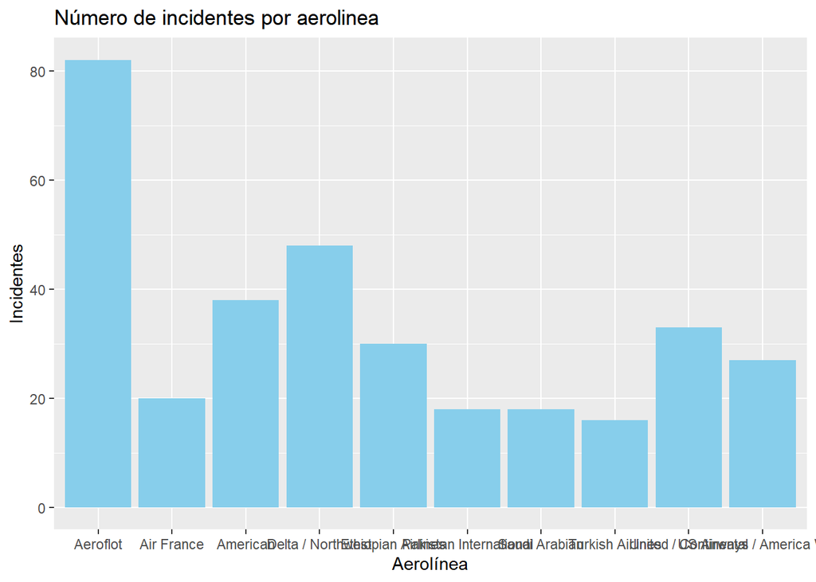

```r
ggplot(top_10,aes(x=airline,y = incidents_85_14))+
  geom_col(fill = ("skyblue"))+
  labs(x="Aerolínea",
         y ="Incidentes",
       title= "Número de incidentes por aerolinea")
```

+ No me gusta porque se enciman los nombres de las aerolíneas, además, no es fácil ver el ranking. + Ordeno de mayor a menor y volteo los ejes.

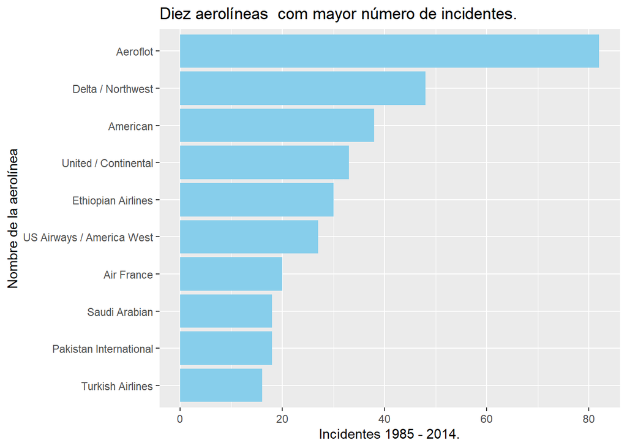

```r
top_10%>%
ggplot(mapping = aes(x =reorder(airline,incidents_85_14),y = incidents_85_14))+
         geom_col(fill ="skyblue")+
         coord_flip()+
         labs(x="Nombre de la aerolínea",
         y ="Incidentes 1985 - 2014.",
       title= "Diez aerolíneas  com mayor número de incidentes.")
```

## Voy crear un nuevo base, larga, para hacer un gráfico en el que pueda comparar los dos períodos.

- Primero selecciono las columnas que necesito.

```r
top10_incidentes <- dplyr::select(top_10,airline,incidents_85_99,incidents_00_14
)
top10_incidentes
```

```
## # A tibble: 10 × 3
##    airline                   incidents_85_99 incidents_00_14
##    <chr>                               <int>           <int>
##  1 Aeroflot                               76               6
##  2 Delta / Northwest                      24              24
##  3 American                               21              17
##  4 United / Continental                   19              14
##  5 Ethiopian Airlines                     25               5
##  6 US Airways / America West              16              11
##  7 Air France                             14               6
##  8 Pakistan International                  8              10
##  9 Saudi Arabian                           7              11
## 10 Turkish Airlines                        8               8
```

- La convierto en larga.

```r
top10_todos <-top10_incidentes |> tidyr::pivot_longer(cols = c('incidents_85_99', 'incidents_00_14'), #¿Qué columnas quiero convertir a renglones?
                    names_to = 'periodo', # nombre de la nueva columna
                    values_to = 'incidentes') # valores que asignarás
top10_todos
```

```
## # A tibble: 20 × 3
##    airline                   periodo         incidentes
##    <chr>                     <chr>                <int>
##  1 Aeroflot                  incidents_85_99         76
##  2 Aeroflot                  incidents_00_14          6
##  3 Delta / Northwest         incidents_85_99         24
##  4 Delta / Northwest         incidents_00_14         24
##  5 American                  incidents_85_99         21
##  6 American                  incidents_00_14         17
##  7 United / Continental      incidents_85_99         19
##  8 United / Continental      incidents_00_14         14
##  9 Ethiopian Airlines        incidents_85_99         25
## 10 Ethiopian Airlines        incidents_00_14          5
## 11 US Airways / America West incidents_85_99         16
## 12 US Airways / America West incidents_00_14         11
## 13 Air France                incidents_85_99         14
## 14 Air France                incidents_00_14          6
## 15 Pakistan International    incidents_85_99          8
## 16 Pakistan International    incidents_00_14         10
## 17 Saudi Arabian             incidents_85_99          7
## 18 Saudi Arabian             incidents_00_14         11
## 19 Turkish Airlines          incidents_85_99          8
## 20 Turkish Airlines          incidents_00_14          8
```

- Hago la gráfica.

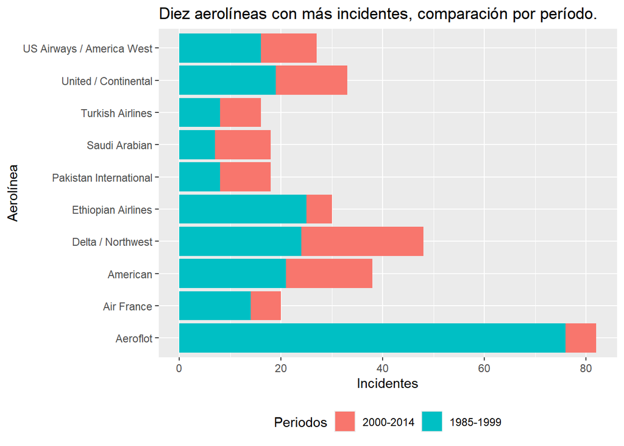

```r
ggplot(top10_todos,aes(x=airline,y = incidentes,fill = periodo))+
  geom_bar(stat = "identity")+
  coord_flip()+
         labs(x="Aerolínea",
         y ="Incidentes",
       title= "Diez aerolíneas con más incidentes, comparación por período.")+
  theme(legend.position = "bottom")+
  guides(fill = guide_legend(title = "Periodos"))+
  scale_fill_hue(labels = c("2000-2014", "1985-1999"))
```

##Actividad 3. +Obtenga las 10 aerolíneas que han tenido el menor número de incidentes. Haga una visualización que permita identificar a éstas. ¿Hay algún cambio en este top 10 antes y después del año 2000?

- Tomo la base de la actividad 1.
- La ordeno ascendentemente.

```r
bottom_10 <- datos_vuelos %>% arrange((incidents_85_14)) %>% head(10)
bottom_10
```

```
## # A tibble: 10 × 12
##    airline          incl_reg_subsidiaries avail_seat_km_per_week incidents_85_99
##    <chr>            <lgl>                                  <dbl>           <int>
##  1 TAP - Air Portu… FALSE                              619130754               0
##  2 Finnair          FALSE                              506464950               1
##  3 Hawaiian Airlin… FALSE                              493877795               0
##  4 Virgin Atlantic  FALSE                             1005248585               1
##  5 Aer Lingus       FALSE                              320906734               2
##  6 Austrian Airlin… FALSE                              358239823               1
##  7 Cathay Pacific   TRUE                              2582459303               0
##  8 Condor           FALSE                              417982610               2
##  9 El Al            FALSE                              335448023               1
## 10 COPA             FALSE                              550491507               3
## # ℹ 8 more variables: fatal_accidents_85_99 <int>, fatalities_85_99 <int>,
## #   incidents_00_14 <int>, fatal_accidents_00_14 <int>, fatalities_00_14 <int>,
## #   incidents_85_14 <int>, fatal_accidents_85_14 <int>, fatalities_85_14 <int>
```

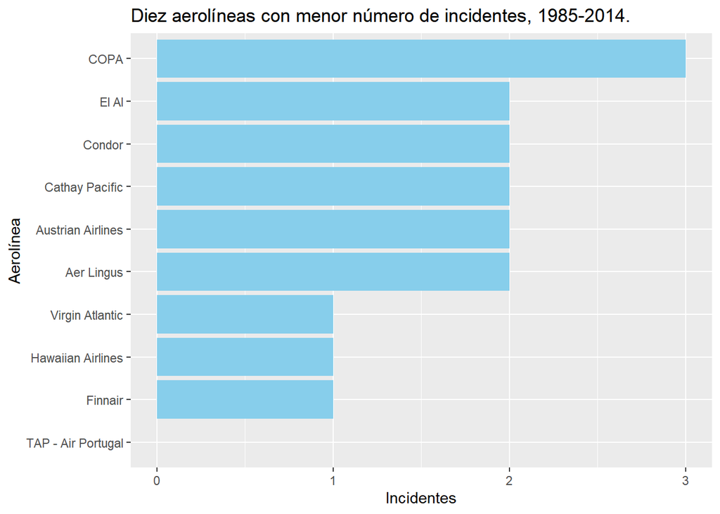

```r
bottom_10%>%
ggplot(mapping = aes(x =reorder(airline,incidents_85_14),y = incidents_85_14))+
         geom_col(fill ="skyblue")+
         coord_flip()+
         labs(x="Aerolínea",
         y ="Incidentes",
       title= "Diez aerolíneas con menor número de incidentes, 1985-2014.")
```

```r
bottom10_incidentes <- dplyr::select(bottom_10,airline,incidents_85_99,incidents_00_14
)
bottom10_incidentes
```

```
## # A tibble: 10 × 3
##    airline            incidents_85_99 incidents_00_14
##    <chr>                        <int>           <int>
##  1 TAP - Air Portugal               0               0
##  2 Finnair                          1               0
##  3 Hawaiian Airlines                0               1
##  4 Virgin Atlantic                  1               0
##  5 Aer Lingus                       2               0
##  6 Austrian Airlines                1               1
##  7 Cathay Pacific                   0               2
##  8 Condor                           2               0
##  9 El Al                            1               1
## 10 COPA                             3               0
```

```r
bottom10_todos <-bottom10_incidentes |> tidyr::pivot_longer(cols = c('incidents_85_99', 'incidents_00_14'), #¿Qué columnas quiero convertir a renglones?
                    names_to = 'periodo', # nombre de la nueva columna
                    values_to = 'incidentes') # valores que asignarás
bottom10_todos
```

```
## # A tibble: 20 × 3
##    airline            periodo         incidentes
##    <chr>              <chr>                <int>
##  1 TAP - Air Portugal incidents_85_99          0
##  2 TAP - Air Portugal incidents_00_14          0
##  3 Finnair            incidents_85_99          1
##  4 Finnair            incidents_00_14          0
##  5 Hawaiian Airlines  incidents_85_99          0
##  6 Hawaiian Airlines  incidents_00_14          1
##  7 Virgin Atlantic    incidents_85_99          1
##  8 Virgin Atlantic    incidents_00_14          0
##  9 Aer Lingus         incidents_85_99          2
## 10 Aer Lingus         incidents_00_14          0
## 11 Austrian Airlines  incidents_85_99          1
## 12 Austrian Airlines  incidents_00_14          1
## 13 Cathay Pacific     incidents_85_99          0
## 14 Cathay Pacific     incidents_00_14          2
## 15 Condor             incidents_85_99          2
## 16 Condor             incidents_00_14          0
## 17 El Al              incidents_85_99          1
## 18 El Al              incidents_00_14          1
## 19 COPA               incidents_85_99          3
## 20 COPA               incidents_00_14          0
```

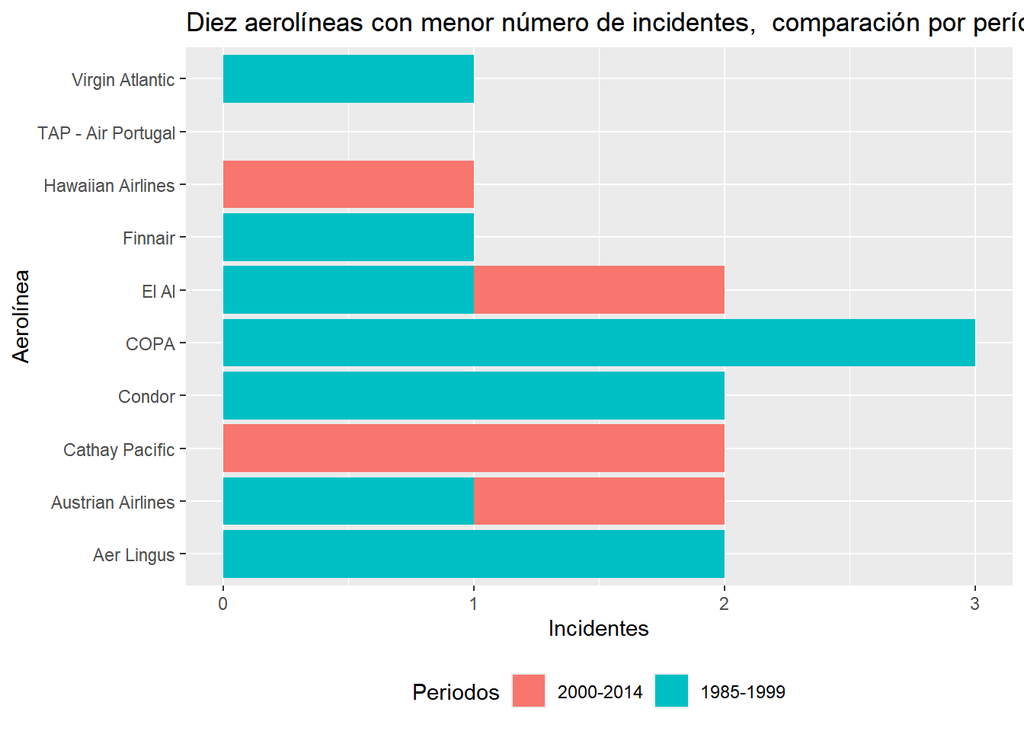

```r
ggplot(bottom10_todos,aes(x=airline,y = incidentes,fill = periodo))+
  geom_bar(stat = "identity")+
  coord_flip()+
         labs(x="Aerolínea",
         y ="Incidentes",
       title= "Diez aerolíneas con menor número de incidentes,  comparación por período.")+
  theme(legend.position = "bottom")+
  guides(fill = guide_legend(title = "Periodos"))+
  scale_fill_hue(labels = c("2000-2014", "1985-1999"))
```

## Actividad 4. + Obtenga las 10 aerolíneas que han tenido el mayor número de muertes. Haga una visualización que permita identificar a estas. ¿Hay algún cambio en este top 10 antes y después del año 2000?

```r
top_10_fatal <- datos_vuelos %>% arrange(desc(fatalities_85_14)) %>% head(10)
top_10
```

```
## # A tibble: 10 × 12
##    airline          incl_reg_subsidiaries avail_seat_km_per_week incidents_85_99
##    <chr>            <lgl>                                  <dbl>           <int>
##  1 Aeroflot         TRUE                              1197672318              76
##  2 Delta / Northwe… TRUE                              6525658894              24
##  3 American         TRUE                              5228357340              21
##  4 United / Contin… TRUE                              7139291291              19
##  5 Ethiopian Airli… FALSE                              488560643              25
##  6 US Airways / Am… TRUE                              2455687887              16
##  7 Air France       FALSE                             3004002661              14
##  8 Pakistan Intern… FALSE                              348563137               8
##  9 Saudi Arabian    FALSE                              859673901               7
## 10 Turkish Airlines FALSE                             1946098294               8
## # ℹ 8 more variables: fatal_accidents_85_99 <int>, fatalities_85_99 <int>,
## #   incidents_00_14 <int>, fatal_accidents_00_14 <int>, fatalities_00_14 <int>,
## #   incidents_85_14 <int>, fatal_accidents_85_14 <int>, fatalities_85_14 <int>
```

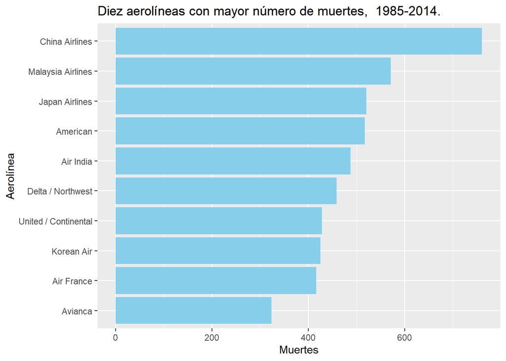

```r
top_10_fatal%>%
ggplot(mapping = aes(x =reorder(airline,fatalities_85_14),y = fatalities_85_14))+
         geom_col(fill ="skyblue")+
         coord_flip()+
         labs(x="Aerolínea",
         y ="Muertes",
       title= "Diez aerolíneas con mayor número de muertes,  1985-2014.")
```

```r
top10_fatalities <- dplyr::select(top_10_fatal,airline,fatalities_85_99,fatalities_00_14
)
top10_fatalities
```

```
## # A tibble: 10 × 3
##    airline              fatalities_85_99 fatalities_00_14
##    <chr>                           <int>            <int>
##  1 China Airlines                    535              225
##  2 Malaysia Airlines                  34              537
##  3 Japan Airlines                    520                0
##  4 American                          101              416
##  5 Air India                         329              158
##  6 Delta / Northwest                 407               51
##  7 United / Continental              319              109
##  8 Korean Air                        425                0
##  9 Air France                         79              337
## 10 Avianca                           323                0
```

```r
top10_fatal_larga <-top10_fatalities |> tidyr::pivot_longer(cols = c('fatalities_85_99', 'fatalities_00_14'), #¿Qué columnas quiero convertir a renglones?
                    names_to = 'periodo', # nombre de la nueva columna
                    values_to = 'muertes') # valores que asignarás
top10_fatal_larga
```

```
## # A tibble: 20 × 3
##    airline              periodo          muertes
##    <chr>                <chr>              <int>
##  1 China Airlines       fatalities_85_99     535
##  2 China Airlines       fatalities_00_14     225
##  3 Malaysia Airlines    fatalities_85_99      34
##  4 Malaysia Airlines    fatalities_00_14     537
##  5 Japan Airlines       fatalities_85_99     520
##  6 Japan Airlines       fatalities_00_14       0
##  7 American             fatalities_85_99     101
##  8 American             fatalities_00_14     416
##  9 Air India            fatalities_85_99     329
## 10 Air India            fatalities_00_14     158
## 11 Delta / Northwest    fatalities_85_99     407
## 12 Delta / Northwest    fatalities_00_14      51
## 13 United / Continental fatalities_85_99     319
## 14 United / Continental fatalities_00_14     109
## 15 Korean Air           fatalities_85_99     425
## 16 Korean Air           fatalities_00_14       0
## 17 Air France           fatalities_85_99      79
## 18 Air France           fatalities_00_14     337
## 19 Avianca              fatalities_85_99     323
## 20 Avianca              fatalities_00_14       0
```

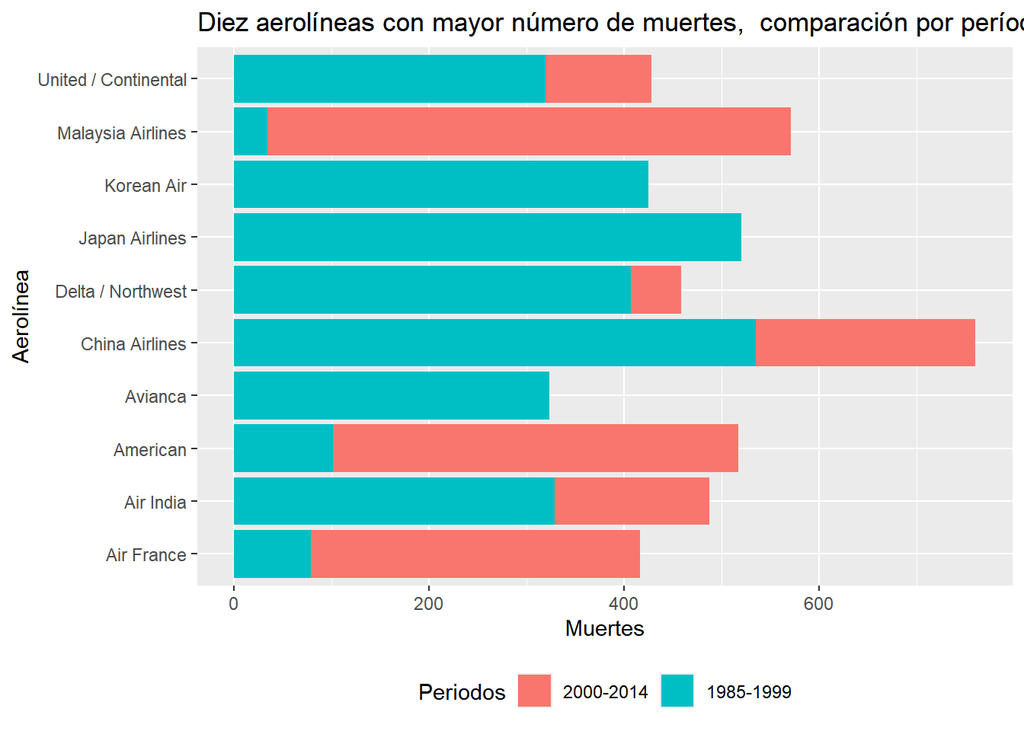

```r
ggplot(top10_fatal_larga,aes(x=airline,y = muertes,fill = periodo))+
  geom_bar(stat = "identity")+
  coord_flip()+
         labs(x="Aerolínea",
         y ="Muertes",
       title= "Diez aerolíneas con mayor número de muertes,  comparación por período.")+
  theme(legend.position = "bottom")+
  guides(fill = guide_legend(title = "Periodos"))+
  scale_fill_hue(labels = c("2000-2014", "1985-1999"))
```

## Actividad 5.

- Obtenga las 10 aerolíneas que han tenido el menor número de muertes. Haga una visualización que permita identificar a éstas. ¿Hay algún cambio en este top 10 antes y después del año 2000?
- Existen 12 aerolíneas con cero muertes en el período 1985-2014, no tiene sentido hacer gráficas ni comparaciones para ellas. Las categorpias aparecen vacías.
- Hago una lista de estas 12 aerolíneas con cero muertes.

```r
zero_muertes <- datos_vuelos %>% filter(fatalities_85_14 == 0)
head(zero_muertes)
```

```
## # A tibble: 6 × 12
##   airline           incl_reg_subsidiaries avail_seat_km_per_week incidents_85_99
##   <chr>             <lgl>                                  <dbl>           <int>
## 1 Aer Lingus        FALSE                              320906734               2
## 2 Aerolineas Argen… FALSE                              385803648               6
## 3 Air Canada        FALSE                             1865253802               2
## 4 Austrian Airlines FALSE                              358239823               1
## 5 British Airways   TRUE                              3179760952               4
## 6 Cathay Pacific    TRUE                              2582459303               0
## # ℹ 8 more variables: fatal_accidents_85_99 <int>, fatalities_85_99 <int>,
## #   incidents_00_14 <int>, fatal_accidents_00_14 <int>, fatalities_00_14 <int>,
## #   incidents_85_14 <int>, fatal_accidents_85_14 <int>, fatalities_85_14 <int>
```

- Voy a usar (kableExtra) para dar formato a la tabla

```r
library(kableExtra)
zm <- select(zero_muertes,airline)
```

```r
kbl(zm, booktabs = T) %>%
kable_styling(latex_options = "striped")
```

| airline |
| --- |
| Aer Lingus |
| Aerolineas Argentinas |
| Air Canada |
| Austrian Airlines |
| British Airways |
| Cathay Pacific |
| Finnair |
| Hawaiian Airlines |
| Qantas |
| Southwest Airlines |
| TAP - Air Portugal |
| Virgin Atlantic |

```r
kbl(zm, caption = "Aerolíneas con cero muertes, 1985-2014", booktabs = T) %>%
kable_styling(latex_options = c("striped", "hold_position")) %>%
  kable_styling(latex_options = c("Aerolínea"))
```

Aerolíneas con cero muertes, 1985-2014

| airline |
| --- |
| Aer Lingus |
| Aerolineas Argentinas |
| Air Canada |
| Austrian Airlines |
| British Airways |
| Cathay Pacific |
| Finnair |
| Hawaiian Airlines |
| Qantas |
| Southwest Airlines |
| TAP - Air Portugal |
| Virgin Atlantic |

- Para hacer las gráficas y comparaciones, creo una nueva base con las aerolíneas que tienen al menos una muerte.
- Queda una base de 44 filas. De esta seleccionaré aquellas con menos muertes para hacer las gráficas y comparaciones.

```r
datos_vuelos_muertes <- datos_vuelos %>% filter(fatalities_85_14 > 0)
datos_vuelos_muertes
```

```
## # A tibble: 44 × 12
##    airline          incl_reg_subsidiaries avail_seat_km_per_week incidents_85_99
##    <chr>            <lgl>                                  <dbl>           <int>
##  1 Aeroflot         TRUE                              1197672318              76
##  2 Aeromexico       TRUE                               596871813               3
##  3 Air France       FALSE                             3004002661              14
##  4 Air India        TRUE                               869253552               2
##  5 Air New Zealand  TRUE                               710174817               3
##  6 Alaska Airlines  TRUE                               965346773               5
##  7 Alitalia         FALSE                              698012498               7
##  8 All Nippon Airw… FALSE                             1841234177               3
##  9 American         TRUE                              5228357340              21
## 10 Avianca          FALSE                              396922563               5
## # ℹ 34 more rows
## # ℹ 8 more variables: fatal_accidents_85_99 <int>, fatalities_85_99 <int>,
## #   incidents_00_14 <int>, fatal_accidents_00_14 <int>, fatalities_00_14 <int>,
## #   incidents_85_14 <int>, fatal_accidents_85_14 <int>, fatalities_85_14 <int>
```

- Selecciono las 10 aerolíneas con menos muertes de entre las que tienen al menos una.

```r
bottom_10_fatal <- datos_vuelos_muertes %>% arrange((fatalities_85_14)) %>% head(10)
bottom_10_fatal
```

```
## # A tibble: 10 × 12
##    airline          incl_reg_subsidiaries avail_seat_km_per_week incidents_85_99
##    <chr>            <lgl>                                  <dbl>           <int>
##  1 All Nippon Airw… FALSE                             1841234177               3
##  2 Lufthansa        TRUE                              3426529504               6
##  3 KLM              TRUE                              1874561773               7
##  4 El Al            FALSE                              335448023               1
##  5 TACA             FALSE                              259373346               3
##  6 Air New Zealand  TRUE                               710174817               3
##  7 Sri Lankan / Ai… FALSE                              325582976               2
##  8 Condor           FALSE                              417982610               2
##  9 LAN Airlines     FALSE                             1001965891               3
## 10 COPA             FALSE                              550491507               3
## # ℹ 8 more variables: fatal_accidents_85_99 <int>, fatalities_85_99 <int>,
## #   incidents_00_14 <int>, fatal_accidents_00_14 <int>, fatalities_00_14 <int>,
## #   incidents_85_14 <int>, fatal_accidents_85_14 <int>, fatalities_85_14 <int>
```

- Grafico de más a menos muertes.

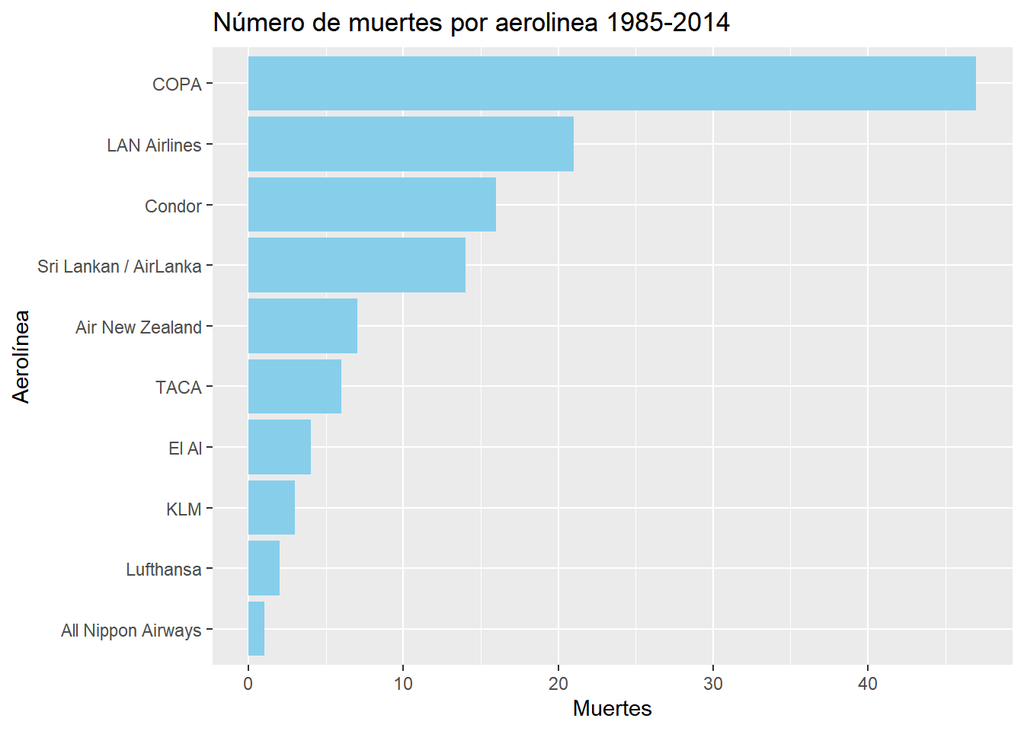

```r
bottom_10_fatal%>%
ggplot(mapping = aes(x =reorder(airline,fatalities_85_14),y = fatalities_85_14))+
         geom_col(fill ="skyblue")+
         coord_flip()+
         labs(x="Aerolínea",
         y ="Muertes",
       title= "Número de muertes por aerolinea 1985-2014")
```

+ Creo una nueva base seleccionando solo aerolínea y muertes por período.

```r
bottom10_fatalities <- dplyr::select(bottom_10_fatal,airline,fatalities_85_99,fatalities_00_14
)
bottom10_fatalities
```

```
## # A tibble: 10 × 3
##    airline               fatalities_85_99 fatalities_00_14
##    <chr>                            <int>            <int>
##  1 All Nippon Airways                   1                0
##  2 Lufthansa                            2                0
##  3 KLM                                  3                0
##  4 El Al                                4                0
##  5 TACA                                 3                3
##  6 Air New Zealand                      0                7
##  7 Sri Lankan / AirLanka               14                0
##  8 Condor                              16                0
##  9 LAN Airlines                        21                0
## 10 COPA                                47                0
```

- Convierto de ancha a larga la base anterior.

```r
bottom10_fatal_larga <-bottom10_fatalities |> tidyr::pivot_longer(cols = c('fatalities_85_99', 'fatalities_00_14'), #¿Qué columnas quiero convertir a renglones?
                    names_to = 'periodo', # nombre de la nueva columna
                    values_to = 'muertes') # valores que asignarás
bottom10_fatal_larga
```

```
## # A tibble: 20 × 3
##    airline               periodo          muertes
##    <chr>                 <chr>              <int>
##  1 All Nippon Airways    fatalities_85_99       1
##  2 All Nippon Airways    fatalities_00_14       0
##  3 Lufthansa             fatalities_85_99       2
##  4 Lufthansa             fatalities_00_14       0
##  5 KLM                   fatalities_85_99       3
##  6 KLM                   fatalities_00_14       0
##  7 El Al                 fatalities_85_99       4
##  8 El Al                 fatalities_00_14       0
##  9 TACA                  fatalities_85_99       3
## 10 TACA                  fatalities_00_14       3
## 11 Air New Zealand       fatalities_85_99       0
## 12 Air New Zealand       fatalities_00_14       7
## 13 Sri Lankan / AirLanka fatalities_85_99      14
## 14 Sri Lankan / AirLanka fatalities_00_14       0
## 15 Condor                fatalities_85_99      16
## 16 Condor                fatalities_00_14       0
## 17 LAN Airlines          fatalities_85_99      21
## 18 LAN Airlines          fatalities_00_14       0
## 19 COPA                  fatalities_85_99      47
## 20 COPA                  fatalities_00_14       0
```

- Hago la gráfica para comparar los dos períodos.

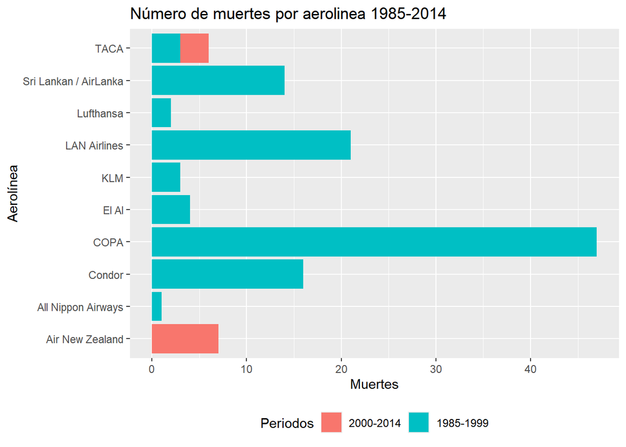

```r
ggplot(bottom10_fatal_larga,aes(x=airline,y = muertes,fill = periodo))+
  geom_bar(stat = "identity")+
  coord_flip()+
         labs(x="Aerolínea",
         y ="Muertes",
       title= "Número de muertes por aerolinea 1985-2014")+
  theme(legend.position = "bottom")+
  guides(fill = guide_legend(title = "Periodos"))+
  scale_fill_hue(labels = c("2000-2014", "1985-1999"))
```